# Assignment 5

Allison Byron

2017-04-25

# The Question

How to improve Hometown Bank’s status in the term deposit market?

My goal is to understand how to increase the number of people who subscribe a term deposit in future marketing campaigns by studying the characteristics of people who have subscribed a term deposit in a past campaign. By identifying the key characteristics that affect if a customer subscribes a deposit or not, the effectiveness of future marketing campaigns can be increased.

Prediction Goals Outlined: *To build a model to predict whether a bank customer is likely to subscribe a term deposit* *To identify predictors that explain if a bank customer is more likely to subscribe a term deposit*

In predicting term deposit subscribers, I will be evaluating the performances of the following supervised learning algorithms: decision tree classification model, k-nearest neighbor (knn) classification model and logistic regression. I will also examine a random forest ensemble model. I am using supervised learning approaches because this method predicts categorical class labels (ex. if a customer subscribes a term deposit or not).

# The Dataset

```r
setwd("M:/Rockhurst/BIA 6301/Assignment 5")
bank<-read.csv("bank-full.csv")
```

*Dataset of 45,211 bank records*

This dataset is related to the direct marketing campaign of Hometown Bank. Hometown Bank’s marketing campaign was based on phone calls.

17 characteristics are reported for each record -

age (number) job (category) marital (category): marital status education (category) default (binary): has credit in default? balance (number): average yearly balance (in euros) housing (binary): has housing loan? loan (binary): has personal loan? contact (category): contact communication type day (number): last contact day of the month month (category): last contact month of year duration (number): last contact duration (in seconds) campaign (number): number of contacts performed during this campaign and for this client (includes last contact) pdays (number): number of days that passed by after the client was contacted from a previous campaign (-1 means client was not previously contacted) previous (number): number of contacts performed before this campaign and for this client poutcome (category): outcome of the previous marketing campaign y (binary): output variable (desired target) - has the client subscribed a term deposit?

Source: Elsalamony, Hany (2014). Bank direct marketing analysis of data mining techniques. International Journal of Computer Applications 85(7): 12-22.

```r
str(bank)
```

```
## 'data.frame':    45211 obs. of  17 variables:
##  $ age      : int  58 44 33 47 33 35 28 42 58 43 ...
##  $ job      : Factor w/ 12 levels "admin.","blue-collar",..: 5 10 3 2 12 5 5 3 6 10 ...
##  $ marital  : Factor w/ 3 levels "divorced","married",..: 2 3 2 2 3 2 3 1 2 3 ...
##  $ education: Factor w/ 4 levels "primary","secondary",..: 3 2 2 4 4 3 3 3 1 2 ...
##  $ default  : Factor w/ 2 levels "no","yes": 1 1 1 1 1 1 1 2 1 1 ...
##  $ balance  : int  2143 29 2 1506 1 231 447 2 121 593 ...
##  $ housing  : Factor w/ 2 levels "no","yes": 2 2 2 2 1 2 2 2 2 2 ...
##  $ loan     : Factor w/ 2 levels "no","yes": 1 1 2 1 1 1 2 1 1 1 ...
##  $ contact  : Factor w/ 3 levels "cellular","telephone",..: 3 3 3 3 3 3 3 3 3 3 ...
##  $ day      : int  5 5 5 5 5 5 5 5 5 5 ...
##  $ month    : Factor w/ 12 levels "apr","aug","dec",..: 9 9 9 9 9 9 9 9 9 9 ...
##  $ duration : int  261 151 76 92 198 139 217 380 50 55 ...
##  $ campaign : int  1 1 1 1 1 1 1 1 1 1 ...
##  $ pdays    : int  -1 -1 -1 -1 -1 -1 -1 -1 -1 -1 ...
##  $ previous : int  0 0 0 0 0 0 0 0 0 0 ...
##  $ poutcome : Factor w/ 4 levels "failure","other",..: 4 4 4 4 4 4 4 4 4 4 ...
##  $ y        : Factor w/ 2 levels "no","yes": 1 1 1 1 1 1 1 1 1 1 ...
```

```r
summary(bank)
```

```
##       age                 job           marital          education
##  Min.   :18.00   blue-collar:9732   divorced: 5207   primary  : 6851
##  1st Qu.:33.00   management :9458   married :27214   secondary:23202
##  Median :39.00   technician :7597   single  :12790   tertiary :13301
##  Mean   :40.94   admin.     :5171                    unknown  : 1857
##  3rd Qu.:48.00   services   :4154
##  Max.   :95.00   retired    :2264
##                  (Other)    :6835
##  default        balance       housing      loan            contact
##  no :44396   Min.   : -8019   no :20081   no :37967   cellular :29285
##  yes:  815   1st Qu.:    72   yes:25130   yes: 7244   telephone: 2906
##              Median :   448                           unknown  :13020
##              Mean   :  1362
##              3rd Qu.:  1428
##              Max.   :102127
##
##       day            month          duration         campaign
##  Min.   : 1.00   may    :13766   Min.   :   0.0   Min.   : 1.000
##  1st Qu.: 8.00   jul    : 6895   1st Qu.: 103.0   1st Qu.: 1.000
##  Median :16.00   aug    : 6247   Median : 180.0   Median : 2.000
##  Mean   :15.81   jun    : 5341   Mean   : 258.2   Mean   : 2.764
##  3rd Qu.:21.00   nov    : 3970   3rd Qu.: 319.0   3rd Qu.: 3.000
##  Max.   :31.00   apr    : 2932   Max.   :4918.0   Max.   :63.000
##                  (Other): 6060
##      pdays          previous           poutcome       y
##  Min.   : -1.0   Min.   :  0.0000   failure: 4901   no :39922
##  1st Qu.: -1.0   1st Qu.:  0.0000   other  : 1840   yes: 5289
##  Median : -1.0   Median :  0.0000   success: 1511
##  Mean   : 40.2   Mean   :  0.5803   unknown:36959
##  3rd Qu.: -1.0   3rd Qu.:  0.0000
##  Max.   :871.0   Max.   :275.0000
##
```

```r
dim(bank)
```

```
## [1] 45211    17
```

```r
names(bank)
```

```
##  [1] "age"       "job"       "marital"   "education" "default"
##  [6] "balance"   "housing"   "loan"      "contact"   "day"
## [11] "month"     "duration"  "campaign"  "pdays"     "previous"
## [16] "poutcome"  "y"
```

In this dataset, the average customer is 41 years old and the most-common jobs are blue-collar and management positions. Married customers accounted for 60% of the phone calls while over half of the phone calls were to customers with a secondary education. Almost all customers did not have credit in default and most did not have a personal loan (84%). The average yearly balance is between -8,019 and 102,127 euros, and I find it interesting that there are negative balances listed.

```r
table(bank$poutcome)
```

```
##
## failure   other success unknown
##    4901    1840    1511   36959
```

```r
prop.table(table(bank$poutcome))
```

```
##
##    failure      other    success    unknown
## 0.10840282 0.04069806 0.03342107 0.81747805
```

I find the poutcome variable to not be as relevant because 82% of the records list ‘unknown’ as their outcome of the previous campaign.

```r
table(bank$y)
```

```
##
##    no   yes
## 39922  5289
```

```r
prop.table(table(bank$y))
```

```
##
##        no       yes
## 0.8830152 0.1169848
```

11.7% subscribed a term deposit while 88.3% did not subscribe.

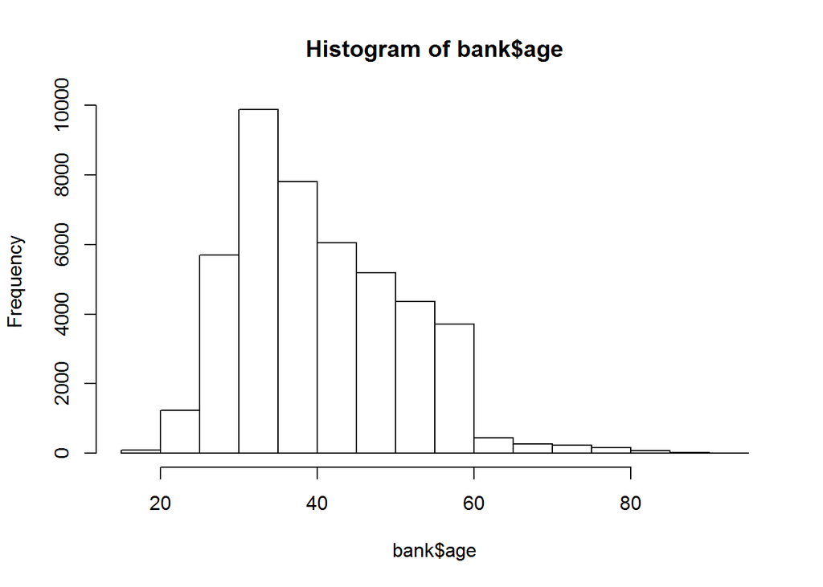

```r
hist(bank$age)
```

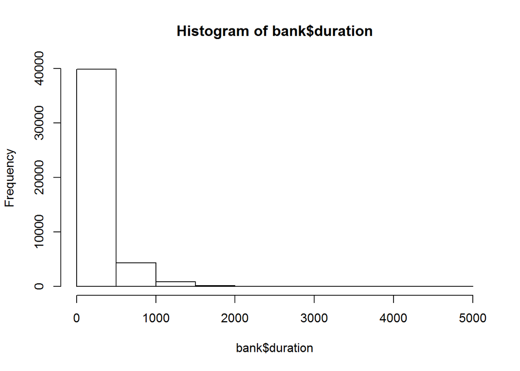

```r
hist(bank$duration)
```

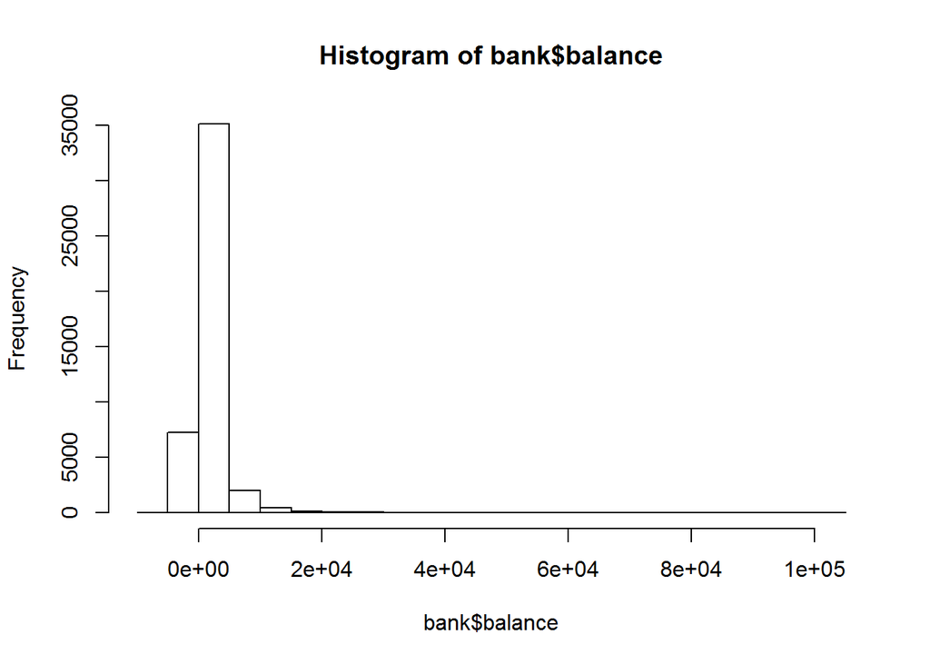

```r
hist(bank$balance)
```

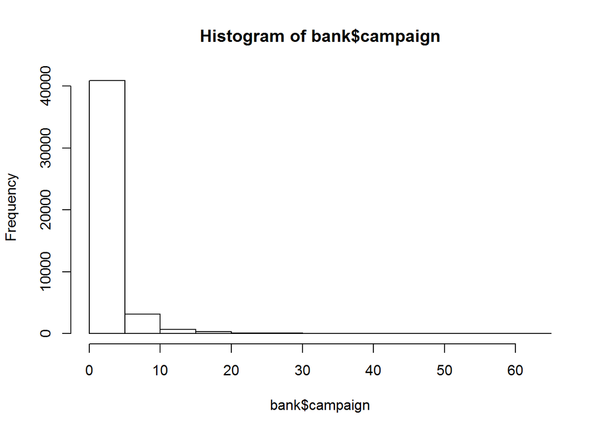

```r
hist(bank$campaign)
```

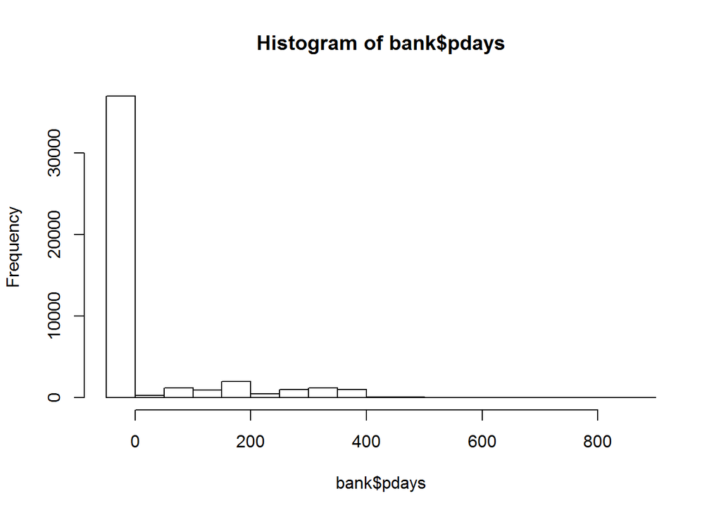

```r
hist(bank$pdays)
```

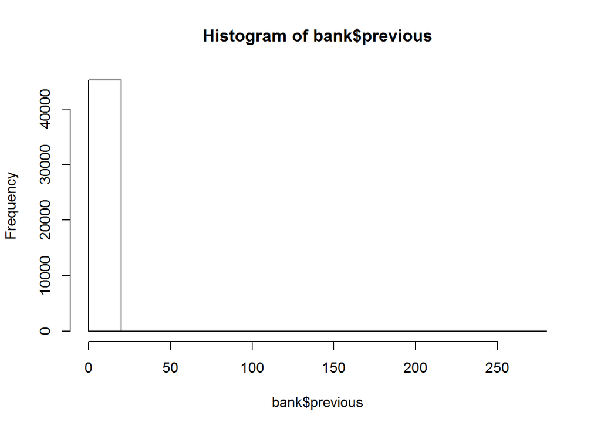

```r
hist(bank$previous)
```

The distribution of the contact duration is right-skewed. The majority of contact phone calls were between 0 and 500 seconds (0-8 minutes).

# Creating a Training and Test Set by Randomizing Observations

Dataset divided into two subsets: training set and a test set. Training set used to “train” our decision tree model. Then, this model is used to predict the observations in our test set to gauge the performance of our prediction model.

Dataset split into 80-20 (80% training and 20% test sets).

```r
set.seed(123) #set a seed to do draws from a random uniform distribution.
bank_rand <- bank[order(runif(45211)), ]
bank_train <- bank_rand[1:36168, ] #Training data set; 36168 observations - 80%
bank_test  <-bank_rand[36169:45211, ] #Test data set; 9043 observations - 20%
```

# 1st Model: Decision Tree - ‘Gini’ splitting criterion

The Decision Tree machine learning method is a powerful classifer that makes complex decisions from sets of simple choices. This method presents the information in the form of a tree structure that can be easily understood. Decision trees follow recursive partitioning (top down greedy divide and conquer approach), partitioning data into interesting segments. The attribute chosen as the most predictive of the target variable is the first split. Observations are continually divided into groups of distinct values where the variable with the most prediction power is chosen before splitting again into another set of branches. The structure of branching decisions used then channels into a final predicted class value. (Lantz 2013, p. 126)

‘Gini’ splitting criterion favors larger partitions and is very simple to implement.

*Using rpart to build a Decision Tree*

```r
library(rpart)
set.seed(123)
bank_rpart <- rpart(bank_train$y~., method="class", parms = list(split="gini"), data=bank_train)

#method="class" --> categorical (yes/no)
```

### Root, Nodes, and Leaves

```r
summary(bank_rpart)
```

```
## Call:
## rpart(formula = bank_train$y ~ ., data = bank_train, method = "class",
##     parms = list(split = "gini"))
##   n= 36168
##
##           CP nsplit rel error    xerror       xstd
## 1 0.03729054      0 1.0000000 1.0000000 0.01443493
## 2 0.02478169      3 0.8881284 0.8921407 0.01373148
## 3 0.02242152      4 0.8633467 0.8732594 0.01360216
## 4 0.01000000      5 0.8409252 0.8484777 0.01342943
##
## Variable importance
## duration poutcome
##       62       37
##
## Node number 1: 36168 observations,    complexity param=0.03729054
##   predicted class=no   expected loss=0.1171478  P(node) =1
##     class counts: 31931  4237
##    probabilities: 0.883 0.117
##   left son=2 (31401 obs) right son=3 (4767 obs)
##   Primary splits:
##       duration < 472.5   to the left,   improve=947.9103, (0 missing)
##       poutcome splits as  LLRL,         improve=724.4430, (0 missing)
##       month    splits as  LLRLLLLRLLRR, improve=417.9358, (0 missing)
##       pdays    < 8.5     to the left,   improve=220.5731, (0 missing)
##       previous < 0.5     to the left,   improve=217.4400, (0 missing)
##
## Node number 2: 31401 observations,    complexity param=0.03729054
##   predicted class=no   expected loss=0.07254546  P(node) =0.8681984
##     class counts: 29123  2278
##    probabilities: 0.927 0.073
##   left son=4 (30408 obs) right son=5 (993 obs)
##   Primary splits:
##       poutcome splits as  LLRL,         improve=610.9063, (0 missing)
##       month    splits as  LLRLLLLRLLRR, improve=381.2099, (0 missing)
##       pdays    < 16      to the left,   improve=191.3843, (0 missing)
##       previous < 0.5     to the left,   improve=188.7893, (0 missing)
##       duration < 201.5   to the left,   improve=150.1715, (0 missing)
##
## Node number 3: 4767 observations,    complexity param=0.03729054
```

[output cut: 58 more lines]

```
##
## Node number 11: 804 observations
##   predicted class=yes  expected loss=0.2885572  P(node) =0.0222296
##     class counts:   232   572
##    probabilities: 0.289 0.711
##
## Node number 12: 3055 observations
##   predicted class=no   expected loss=0.306383  P(node) =0.08446693
##     class counts:  2119   936
##    probabilities: 0.694 0.306
##
## Node number 13: 159 observations
##   predicted class=yes  expected loss=0.2012579  P(node) =0.004396151
##     class counts:    32   127
##    probabilities: 0.201 0.799
```

### Visualizing the Gini Decision Tree

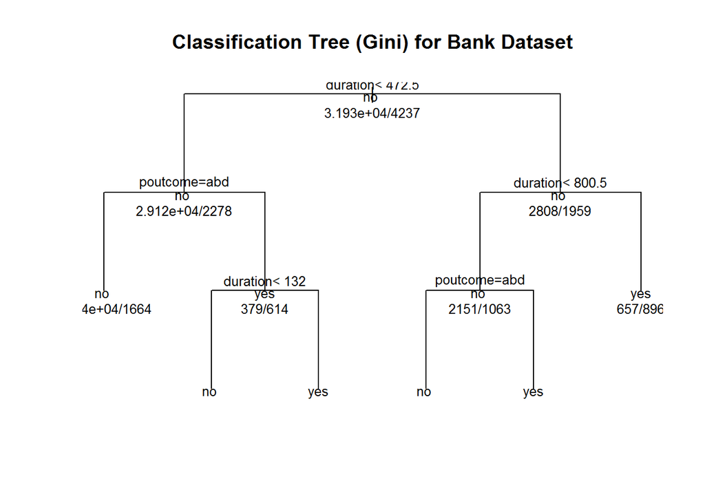

```r
# Visual #1
plot(bank_rpart, uniform=TRUE, main="Classification Tree (Gini) for Bank Dataset")
text(bank_rpart, use.n=TRUE, all=TRUE, cex=0.8)
```

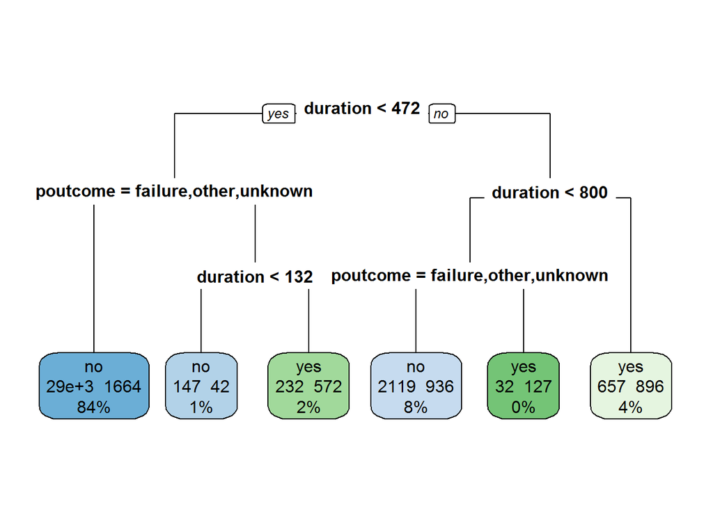

```r
# Visual #2
library(rpart.plot)
rpart.plot(bank_rpart, type=0, extra=101)
```

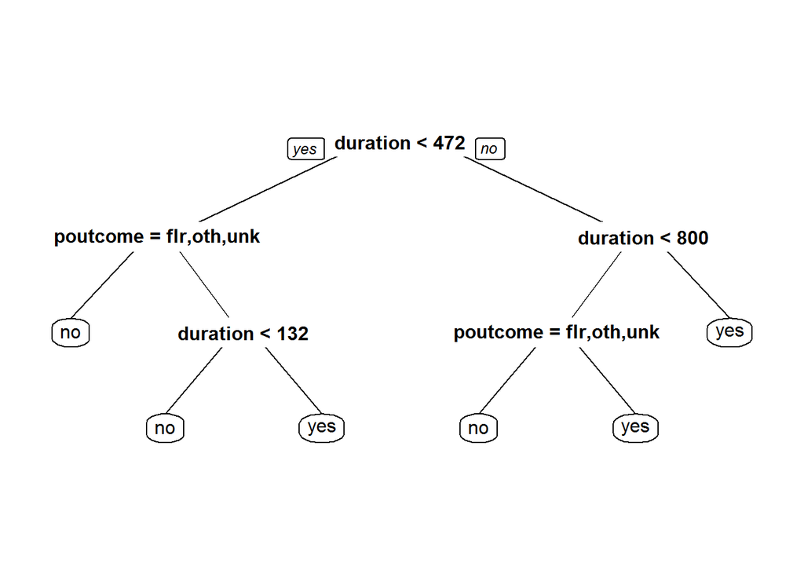

```r
prp(bank_rpart)

# Visual #3
library(party)
```

```r
library(partykit)
```

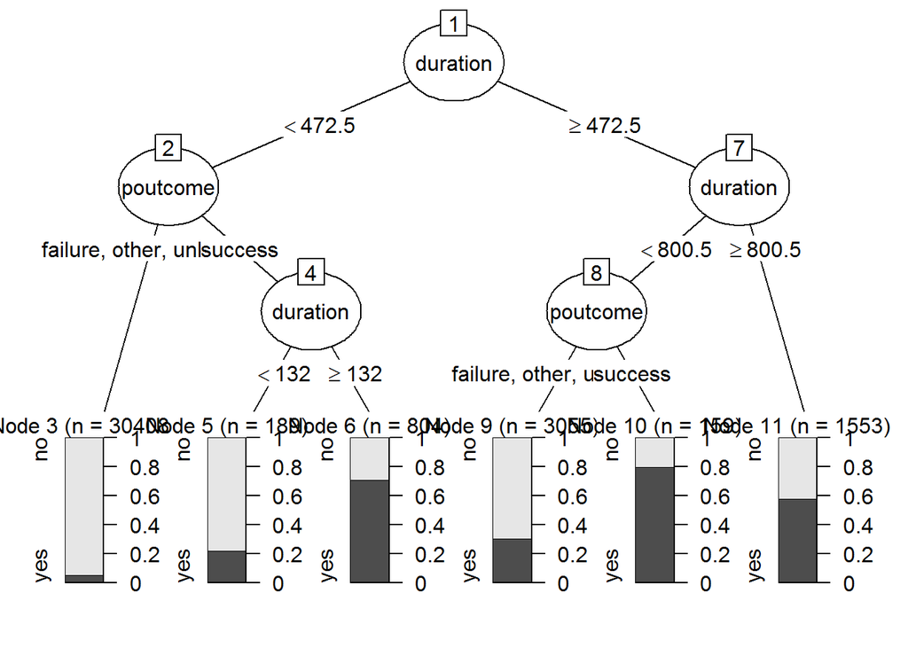

```r
bank_party<-as.party(bank_rpart)
plot(bank_party)
```

In this model, the data has been divided up into 6 classes (in nodes labeled 3, 5, 6, 9, 10, 11). The most important variable out of 16 predictors is ‘duration’ in helping to classify the bank clients as term deposit subscribers or non-subscribers. At the highest level, the data is divided into two categories according to the contact duration: either less than 473 seconds or greater than or equal to 473 seconds.

## Evaluating Model Performance - ‘Gini’ Decision Tree

```r
library(caret)
actual <- bank_test$y
predicted <- predict(bank_rpart, bank_test, type="class")
results.matrix <- confusionMatrix(predicted, actual, positive="yes")
print(results.matrix)
```

```
## Confusion Matrix and Statistics
##
##           Reference
## Prediction   no  yes
##        no  7754  683
##        yes  237  369
##
##                Accuracy : 0.8983
##                  95% CI : (0.8918, 0.9044)
##     No Information Rate : 0.8837
##     P-Value [Acc > NIR] : 5.635e-06
##
##                   Kappa : 0.3935
##  Mcnemar's Test P-Value : < 2.2e-16
##
##             Sensitivity : 0.35076
##             Specificity : 0.97034
##          Pos Pred Value : 0.60891
##          Neg Pred Value : 0.91905
##              Prevalence : 0.11633
##          Detection Rate : 0.04081
##    Detection Prevalence : 0.06701
##       Balanced Accuracy : 0.66055
##
##        'Positive' Class : yes
##
```

True positives (TP) = 369 *369 cases in which we predicted yes (subscribed a term deposit), and the clients did subscribe a term deposit.*

False positives (FP) = 237 *237 cases where we predicted yes (subscribed a term deposit), and the clients did not actually subscribe a term deposit.*

False negatives (FN) = 683 *683 cases where we predicted no (did not subscribe a term deposit), and the clients actually did subscribe a term deposit.*

Accuracy = 89.8% *Overall, the classifier is correct 89.83% of the time.*

Sensitivity = 35.1% *When a client actually did subscribe a term deposit, our model predicts yes (subscribed a term deposit) 35.1% of the time*

Specificity = 97% *When a client actually did not subscribe a term deposit, our model predicts no (did not subscribe a term deposit) 97% of the time*

The rate of correctly classified negative (specificity) is very high (97%), which demonstrates that this model does well in predicting when a client does not subscribe a term deposit. The ratio of the number of correctly classified cases (accuracy) is fairly high as well (89.8%). However, the rate of correctly classified positive (sensitivity) is not as high as I would have hoped, where our model predicts yes 35.1% of the time when a client actually does subscribe.

## Visualizing Cross Validation Results of ‘Gini’ Decision Tree

```r
cptable<-printcp(bank_rpart)
```

```
##
## Classification tree:
## rpart(formula = bank_train$y ~ ., data = bank_train, method = "class",
##     parms = list(split = "gini"))
##
## Variables actually used in tree construction:
## [1] duration poutcome
##
## Root node error: 4237/36168 = 0.11715
##
## n= 36168
##
##         CP nsplit rel error  xerror     xstd
## 1 0.037291      0   1.00000 1.00000 0.014435
## 2 0.024782      3   0.88813 0.89214 0.013731
## 3 0.022422      4   0.86335 0.87326 0.013602
## 4 0.010000      5   0.84093 0.84848 0.013429
```

```r
cptable
```

```
##           CP nsplit rel error    xerror       xstd
## 1 0.03729054      0 1.0000000 1.0000000 0.01443493
## 2 0.02478169      3 0.8881284 0.8921407 0.01373148
## 3 0.02242152      4 0.8633467 0.8732594 0.01360216
## 4 0.01000000      5 0.8409252 0.8484777 0.01342943
```

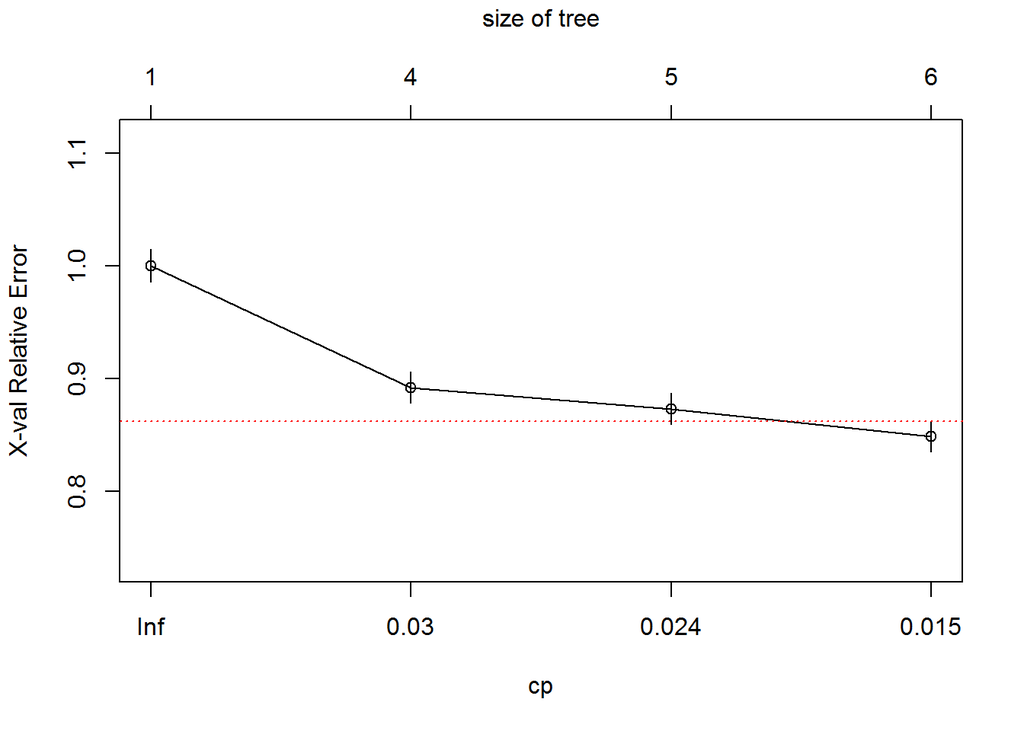

```r
plotcp(bank_rpart, minline=TRUE, col="red")
```

### Prune ‘Gini’ Decision Tree

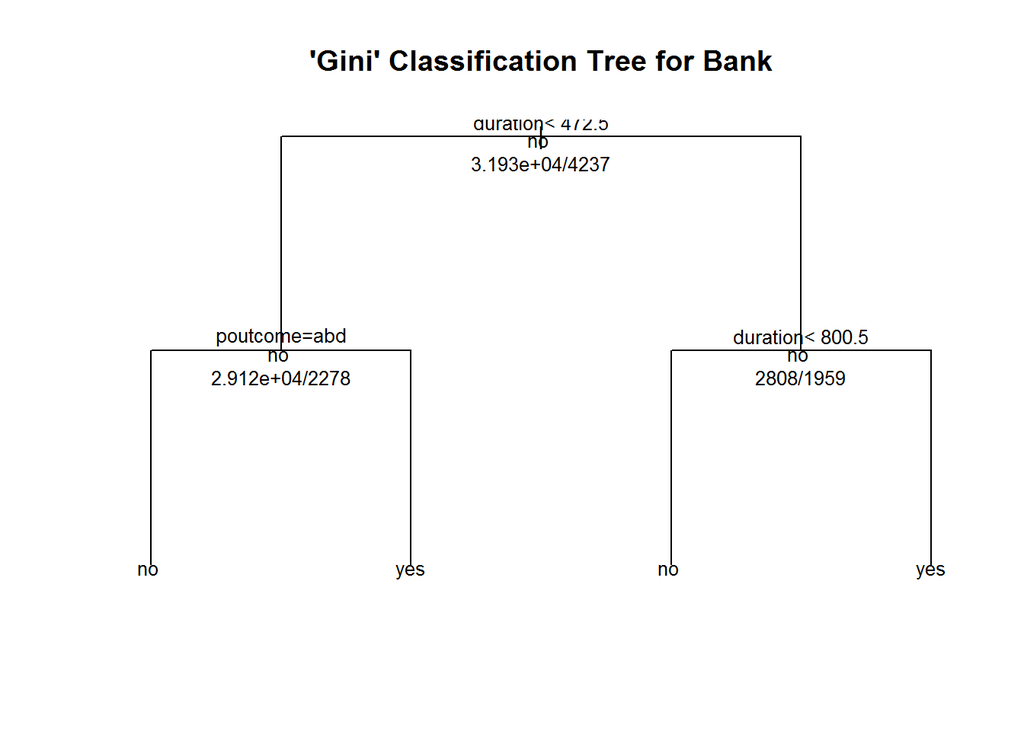

```r
Pruned_bank_rpart <-prune(bank_rpart,cp=.03) #Change the cp and see what happens.

plot(Pruned_bank_rpart, uniform=TRUE,main="'Gini' Classification Tree for Bank")
text(Pruned_bank_rpart, use.n=TRUE, all=TRUE, cex=.8)
```

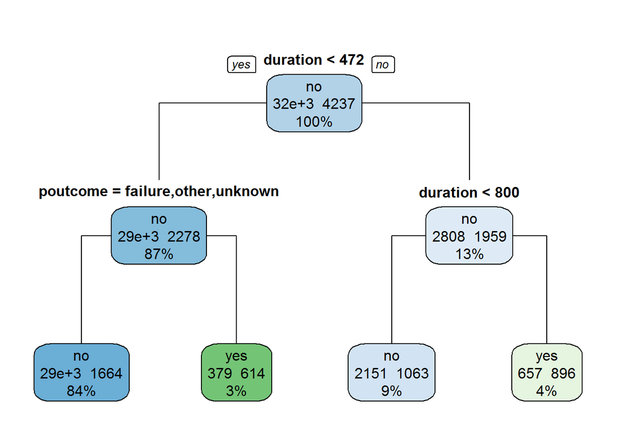

```r
rpart.plot(Pruned_bank_rpart, type=1, extra=101)
```

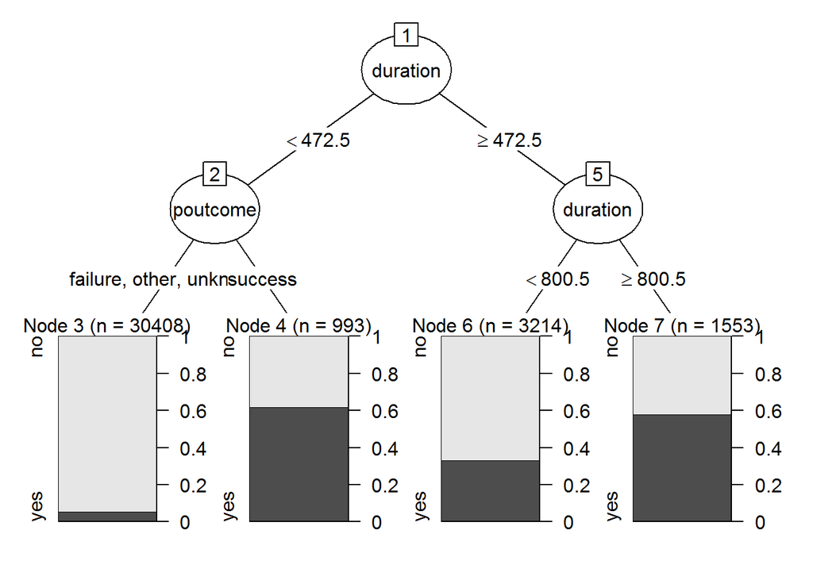

```r
Pruned_bank_party<-as.party(Pruned_bank_rpart)
plot(Pruned_bank_party)
```

## Visualizing Cross Validation Results of Pruned ‘Gini’ Decision Tree

```r
actual <- bank_test$y
predicted <- predict(Pruned_bank_rpart, bank_test, type="class")
results.matrix <- confusionMatrix(predicted, actual, positive="yes")
print(results.matrix)
```

```
## Confusion Matrix and Statistics
##
##           Reference
## Prediction   no  yes
##        no  7721  692
##        yes  270  360
##
##                Accuracy : 0.8936
##                  95% CI : (0.8871, 0.8999)
##     No Information Rate : 0.8837
##     P-Value [Acc > NIR] : 0.001495
##
##                   Kappa : 0.3735
##  Mcnemar's Test P-Value : < 2.2e-16
##
##             Sensitivity : 0.34221
##             Specificity : 0.96621
##          Pos Pred Value : 0.57143
##          Neg Pred Value : 0.91775
##              Prevalence : 0.11633
##          Detection Rate : 0.03981
##    Detection Prevalence : 0.06967
##       Balanced Accuracy : 0.65421
##
##        'Positive' Class : yes
##
```

True positives (TP) = 360 *360 cases in which we predicted yes (subscribed a term deposit), and the clients did subscribe a term deposit.*

False positives (FP) = 270 *270 cases where we predicted yes (subscribed a term deposit), and the clients did not actually subscribe a term deposit.*

False negatives (FN) = 692 *692 cases where we predicted no (did not subscribe a term deposit), and the clients actually did subscribe a term deposit.*

Accuracy = 89.4% *Overall, the classifier is correct 89.4% of the time.*

Sensitivity = 34.2% *When a client actually did subscribe a term deposit, our model predicts yes (subscribed a term deposit) 34.2% of the time*

Since the pruned tree slightly under performed compared to the non-pruned tree, I will be using my first decision tree model’s (non-pruned) results when providing my final recommendations.

# 2nd Model - k-Nearest Neighbor (kNN): A Lazy Classification Model

The kNN model uses the principle that data is classified by placing it in the same category as similar or “nearest” neighbors. Neighbors are compared using distance, where the most common way to measure distance is by the shortest direct route, also known as “Euclidean distance”. The kNN algorithm is simple yet effective. (Lantz 2013, p. 65)

*How many neighbors (k)?* When choosing the number of k, it should be considered that a large k reduces the variance caused by noisy data, but it can cause bias in that we risk ignoring small and important patterns. (Lantz 2013, p. 71)

## Data transformation / Cleaning the data

*kNN requires data transformation into a standard range*

```r
bank_train_knn <- bank_train
bank_test_knn <- bank_test
```

Create dummy variables for ‘job’:

```r
job = factor(bank_train_knn$job)
dummies = model.matrix(~job-1)
bank_train_knn <- cbind(bank_train_knn,dummies)
bank_train_knn <- bank_train_knn[-2]
```

```r
job = factor(bank_test_knn$job)
dummies = model.matrix(~job-1)
bank_test_knn <- cbind(bank_test_knn,dummies)
bank_test_knn <- bank_test_knn[-2]
```

Create dummy variables for ‘marital’:

```r
marital = factor(bank_train_knn$marital)
dummies2 = model.matrix(~marital-1)
bank_train_knn <- cbind(bank_train_knn,dummies2)
bank_train_knn <- bank_train_knn[-2]
```

```r
marital = factor(bank_test_knn$marital)
dummies2 = model.matrix(~marital-1)
bank_test_knn <- cbind(bank_test_knn,dummies2)
bank_test_knn <- bank_test_knn[-2]
```

Create dummy variables for ‘education’:

```r
education = factor(bank_train_knn$education)
dummies3 = model.matrix(~education-1)
bank_train_knn <- cbind(bank_train_knn,dummies3)
bank_train_knn <- bank_train_knn[-2]
```

```r
education = factor(bank_test_knn$education)
dummies3 = model.matrix(~education-1)
bank_test_knn <- cbind(bank_test_knn,dummies3)
bank_test_knn <- bank_test_knn[-2]
```

Create dummy variables for ‘contact’:

```r
contact = factor(bank_train_knn$contact)
dummies4 = model.matrix(~contact-1)
bank_train_knn <- cbind(bank_train_knn,dummies4)
bank_train_knn <- bank_train_knn[-6]
```

```r
contact = factor(bank_test_knn$contact)
dummies4 = model.matrix(~contact-1)
bank_test_knn <- cbind(bank_test_knn,dummies4)
bank_test_knn <- bank_test_knn[-6]
```

Create dummy variables for ‘poutcome’:

```r
poutcome = factor(bank_train_knn$poutcome)
dummies5 = model.matrix(~poutcome-1)
bank_train_knn <- cbind(bank_train_knn,dummies5)
bank_train_knn <- bank_train_knn[-12]
```

```r
poutcome = factor(bank_test_knn$poutcome)
dummies5 = model.matrix(~poutcome-1)
bank_test_knn <- cbind(bank_test_knn,dummies5)
bank_test_knn <- bank_test_knn[-12]
```

Create dummy variables for ‘month’:

```r
month = factor(bank_train_knn$month)
dummies6 = model.matrix(~month-1)
bank_train_knn <- cbind(bank_train_knn,dummies6)
bank_train_knn <- bank_train_knn[-7]
```

```r
month = factor(bank_test_knn$month)
dummies6 = model.matrix(~month-1)
bank_test_knn <- cbind(bank_test_knn,dummies6)
bank_test_knn <- bank_test_knn[-7]
```

```r
#Rearranging the columns so that our target variable is first
bank_train_knn <- bank_train_knn[,c(11,1:10,12:49)]
bank_test_knn<-bank_test_knn[,c(11,1:10,12:49)]
```

```r
bank_train_knn$defaultyes <-ifelse(bank_train_knn$default=="yes",1,0) #if default = yes, 1; if Not, 0.
bank_train_knn<-bank_train_knn[,-3] #We do not need the default variable anymore.

bank_test_knn$defaultyes <-ifelse(bank_test_knn$default=="yes",1,0) #if default = yes, 1; if Not, 0.
bank_test_knn<-bank_test_knn[,-3] #We do not need the default variable anymore.
```

```r
bank_train_knn$housingyes <-ifelse(bank_train_knn$housing=="yes",1,0)
bank_train_knn<-bank_train_knn[,-4]

bank_test_knn$housingyes <-ifelse(bank_test_knn$housing=="yes",1,0)
bank_test_knn<-bank_test_knn[,-4]
```

```r
bank_train_knn$loanyes <-ifelse(bank_train_knn$loan=="yes",1,0)
bank_train_knn<-bank_train_knn[,-4]

bank_test_knn$loanyes <-ifelse(bank_test_knn$loan=="yes",1,0)
bank_test_knn<-bank_test_knn[,-4]
```

```r
names(bank_train_knn)
```

```
##  [1] "y"                  "age"                "balance"
##  [4] "day"                "duration"           "campaign"
##  [7] "pdays"              "previous"           "jobadmin."
## [10] "jobblue-collar"     "jobentrepreneur"    "jobhousemaid"
## [13] "jobmanagement"      "jobretired"         "jobself-employed"
## [16] "jobservices"        "jobstudent"         "jobtechnician"
## [19] "jobunemployed"      "jobunknown"         "maritaldivorced"
## [22] "maritalmarried"     "maritalsingle"      "educationprimary"
## [25] "educationsecondary" "educationtertiary"  "educationunknown"
## [28] "contactcellular"    "contacttelephone"   "contactunknown"
## [31] "poutcomefailure"    "poutcomeother"      "poutcomesuccess"
## [34] "poutcomeunknown"    "monthapr"           "monthaug"
## [37] "monthdec"           "monthfeb"           "monthjan"
## [40] "monthjul"           "monthjun"           "monthmar"
## [43] "monthmay"           "monthnov"           "monthoct"
## [46] "monthsep"           "defaultyes"         "housingyes"
## [49] "loanyes"
```

```r
names(bank_test_knn)
```

```
##  [1] "y"                  "age"                "balance"
##  [4] "day"                "duration"           "campaign"
##  [7] "pdays"              "previous"           "jobadmin."
## [10] "jobblue-collar"     "jobentrepreneur"    "jobhousemaid"
## [13] "jobmanagement"      "jobretired"         "jobself-employed"
## [16] "jobservices"        "jobstudent"         "jobtechnician"
## [19] "jobunemployed"      "jobunknown"         "maritaldivorced"
## [22] "maritalmarried"     "maritalsingle"      "educationprimary"
## [25] "educationsecondary" "educationtertiary"  "educationunknown"
## [28] "contactcellular"    "contacttelephone"   "contactunknown"
## [31] "poutcomefailure"    "poutcomeother"      "poutcomesuccess"
## [34] "poutcomeunknown"    "monthapr"           "monthaug"
## [37] "monthdec"           "monthfeb"           "monthjan"
## [40] "monthjul"           "monthjun"           "monthmar"
## [43] "monthmay"           "monthnov"           "monthoct"
## [46] "monthsep"           "defaultyes"         "housingyes"
## [49] "loanyes"
```

## Min-Max Normalization

Breakdown of the 49 variables:

Column 1: target variable Columns 2-8: phone call detail variables Columns 9-49: dummy variables

Need to do min-max normalization for columns 2-7 and then add that with our other columns (already on the 0-1 scale).

```r
customers_train<-bank_train_knn[,2:8]
normalize<- function(x){return((x-min(x))/(max(x)-min(x)))}
customers_train_n<-as.data.frame(lapply(customers_train, normalize))
```

```r
customers_test<-bank_test_knn[,2:8]
normalize2<- function(x){return((x-min(x))/(max(x)-min(x)))}
customers_test_n<-as.data.frame(lapply(customers_test, normalize2))
```

```r
# Check to see if normalization was done correctly
summary(customers_train$balance)
```

```
##    Min. 1st Qu.  Median    Mean 3rd Qu.    Max.
##   -8019      72     451    1358    1433   98420
```

```r
summary(customers_train_n$balance)
```

```
##    Min. 1st Qu.  Median    Mean 3rd Qu.    Max.
## 0.00000 0.07602 0.07958 0.08810 0.08880 1.00000
```

```r
# Combine the normalized variables with our dummy variables and the target variable.
bank_train_n<-cbind(bank_train_knn[,c(1,9:49)], customers_train_n[,])
bank_train_n<-bank_train_n[complete.cases(bank_train_n),]

bank_test_n<-cbind(bank_test_knn[,c(1,9:49)], customers_test_n[,])
bank_test_n<-bank_test_n[complete.cases(bank_test_n),]
```

## Train and Test Sets

*Same training and test set used in Decision Tree model* Dataset divided into two subsets: training set and a test set. Training set used to “train” our kNN model. Then, this model is used to predict the observations in our test set to gauge the performance of our prediction model.

Dataset split into 80-20 (80% training and 20% test sets).

```r
bank_train_n_knn <- bank_train_n[1:36168,2:49]
bank_test_n_knn <- bank_test_n[1:9043,2:49]

bank_train_n_labels<-bank_train_n[1:36168,1]
bank_test_n_labels<-bank_test_n[1:9043,1]
```

- Using the **class** package to perform kNN.  
  Suggestion: start with k = square root of the number of observations & using an odd k. sqrt(45211) = 213.

```r
library(class)
set.seed(123)
bank_pred_knn<-knn(train=bank_train_n_knn, test=bank_test_n_knn, cl=bank_train_n_labels, k=21)
# k = 213 takes a long time to run, so I went with a smaller k
```

## Evaluating kNN Model Performance

A positive case in dataset as a client who subscribed a term deposit. A negative case is a client who did not.

```r
library(gmodels)

CrossTable(x=bank_test_n_labels, y=bank_pred_knn, prob.chisq=FALSE)
```

```
##
##
##    Cell Contents
## |-------------------------|
## |                       N |
## | Chi-square contribution |
## |           N / Row Total |
## |           N / Col Total |
## |         N / Table Total |
## |-------------------------|
##
##
## Total Observations in Table:  9043
##
##
##                    | bank_pred_knn
## bank_test_n_labels |        no |       yes | Row Total |
## -------------------|-----------|-----------|-----------|
##                 no |      7907 |        84 |      7991 |
##                    |     2.805 |    93.997 |           |
##                    |     0.989 |     0.011 |     0.884 |
##                    |     0.900 |     0.321 |           |
##                    |     0.874 |     0.009 |           |
## -------------------|-----------|-----------|-----------|
##                yes |       874 |       178 |      1052 |
##                    |    21.304 |   714.006 |           |
##                    |     0.831 |     0.169 |     0.116 |
##                    |     0.100 |     0.679 |           |
##                    |     0.097 |     0.020 |           |
## -------------------|-----------|-----------|-----------|
##       Column Total |      8781 |       262 |      9043 |
##                    |     0.971 |     0.029 |           |
## -------------------|-----------|-----------|-----------|
##
##
```

```r
TP = 178
TN = 7907
FP = 84
FN = 874

Sensitivity = TP/(TP+FN) #true positive rate; recall; TP/(TP+FN)
Specificity = TN/(TN+FP) #how often is the prediction negative when actual is negative?
Precision = TP/(TP+FP) #how often is prediction positive when actual is positive?
Accuracy = (TP+TN)/(TP+TN+FP+FN) #how often is classifier correct

Value<-round(c(TP,TN,FP,FN,Sensitivity,Specificity,Precision,Accuracy),digits=3)
Measure<-c("True Positive","True Negative","False Positive","False Negative","Sensitivity/Recall=TP/(TN+FP)",
         "Specificity=TN/(TN+TP)","Precision=TP/(TP+FP)","Accuracy=(TP+TN)/total")

table<-as.data.frame(cbind(Measure,Value))

library(knitr)

kable(table)
```

[output not shown]

False positives (FP) = 84 *84 cases where we predicted yes (subscribed to term deposit), and the clients did not actually subscribe a term deposit.*

False negatives (FN) = 874 *874 cases where we predicted no (did not subscribe to term deposit), and the clients actually did subscribe to a term deposit.*

Accuracy = 89.4% *Overall, the classifier is correct 89.4% of the time.*

Sensitivity = 16.9% *When a client actually did subscribe a term deposit, our model predicts yes (subscribed a term deposit) 16.9% of the time*

Specificity = 98.9% *When a client actually did not subscribe a term deposit, our model predicts no (did not subscribe a term deposit) 98.9% of the time*

The rate of correctly classified negative (specificity) is very high (98.9%), which demonstrates that this model does extremely well in predicting when a client does not subscribe a term deposit. The ratio of the number of correctly classified cases (accuracy) is high as well (89.4%). However, the rate of correctly classified positive (sensitivity) is fairly low, especially compared to the sensitivity rate in our decision tree model. This sensitivity indicates that our model predicts yes 16.9% of the time when a client actually does subscribe.

# Model #3 - Logistic Regression

Logistic regression is used to model a binary categorical outcome, in our case, the ‘y’ variable which indicates if the client has subscribed a term deposit. Maximum likelihood is used to fit the logistic regression, where our goal is to have estimates for betas so that the predicted predicted probability corresponds strongly to the observed data.

### Logit Model

```r
bank_train_logit<-bank_train

bank_train_logitmodel <- glm(y~., data=bank_train_logit, family=binomial()) #Fit a logistic regression

summary(bank_train_logitmodel) #coefficients are presented as log-odds (probabilities on logit scale)
```

```
##
## Call:
## glm(formula = y ~ ., family = binomial(), data = bank_train_logit)
##
## Deviance Residuals:
##     Min       1Q   Median       3Q      Max
## -5.7549  -0.3712  -0.2491  -0.1463   3.4814
##
## Coefficients:
##                      Estimate Std. Error z value Pr(>|z|)
## (Intercept)        -2.477e+00  2.052e-01 -12.076  < 2e-16 ***
## age                -2.052e-04  2.467e-03  -0.083  0.93370
## jobblue-collar     -3.362e-01  8.239e-02  -4.081 4.49e-05 ***
## jobentrepreneur    -3.775e-01  1.431e-01  -2.639  0.00833 **
## jobhousemaid       -5.636e-01  1.573e-01  -3.583  0.00034 ***
## jobmanagement      -1.389e-01  8.268e-02  -1.680  0.09290 .
## jobretired          2.445e-01  1.094e-01   2.234  0.02546 *
## jobself-employed   -2.632e-01  1.242e-01  -2.120  0.03400 *
## jobservices        -2.249e-01  9.539e-02  -2.357  0.01841 *
## jobstudent          4.941e-01  1.221e-01   4.046 5.21e-05 ***
## jobtechnician      -1.639e-01  7.780e-02  -2.107  0.03512 *
## jobunemployed      -1.079e-01  1.250e-01  -0.863  0.38800
## jobunknown         -7.941e-02  2.485e-01  -0.320  0.74930
## maritalmarried     -2.122e-01  6.582e-02  -3.225  0.00126 **
## maritalsingle       5.758e-02  7.518e-02   0.766  0.44371
## educationsecondary  1.267e-01  7.262e-02   1.745  0.08097 .
## educationtertiary   3.516e-01  8.428e-02   4.171 3.03e-05 ***
## educationunknown    1.522e-01  1.177e-01   1.293  0.19617
## defaultyes         -1.421e-01  1.879e-01  -0.756  0.44961
## balance             1.269e-05  6.056e-06   2.096  0.03606 *
## housingyes         -7.184e-01  4.956e-02 -14.495  < 2e-16 ***
## loanyes            -4.192e-01  6.748e-02  -6.212 5.22e-10 ***
## contacttelephone   -2.180e-01  8.491e-02  -2.567  0.01026 *
## contactunknown     -1.636e+00  8.224e-02 -19.892  < 2e-16 ***
## day                 1.137e-02  2.789e-03   4.077 4.56e-05 ***
## monthaug           -7.281e-01  8.861e-02  -8.217  < 2e-16 ***
## monthdec            5.563e-01  2.003e-01   2.777  0.00548 **
## monthfeb           -1.276e-01  9.983e-02  -1.278  0.20114
## monthjan           -1.405e+00  1.411e-01  -9.962  < 2e-16 ***
## monthjul           -7.833e-01  8.646e-02  -9.059  < 2e-16 ***
```

[output cut: 8 more lines]

```
## pdays              -2.459e-05  3.443e-04  -0.071  0.94307
## previous            8.366e-03  6.430e-03   1.301  0.19323
## poutcomeother       1.459e-01  1.008e-01   1.447  0.14789
## poutcomesuccess     2.284e+00  9.245e-02  24.707  < 2e-16 ***
## poutcomeunknown    -1.230e-01  1.041e-01  -1.181  0.23748
## ---
## Signif. codes:  0 '***' 0.001 '**' 0.01 '*' 0.05 '.' 0.1 ' ' 1
##
## (Dispersion parameter for binomial family taken to be 1)
##
##     Null deviance: 26128  on 36167  degrees of freedom
## Residual deviance: 17086  on 36125  degrees of freedom
## AIC: 17172
##
## Number of Fisher Scoring iterations: 6
```

The variables that best explain if a client subscribes a term deposit are: *jobblue-collar, jobhousemaid, jobstudent, educationtertiary, housingyes, loanyes, contactunknown, day, month, duration, campaign, poutcomesuccess*

Reduced logit model:

```r
bank_train_logitmodel_reduced <- glm(y~job+education+housing+loan+contact+day+month+duration+campaign+poutcome, data=bank_train_logit, family=binomial()) #Fit a logistic regression
summary(bank_train_logitmodel_reduced) #coefficients are presented as log-odds (probabilities on logit scale)
```

```
##
## Call:
## glm(formula = y ~ job + education + housing + loan + contact +
##     day + month + duration + campaign + poutcome, family = binomial(),
##     data = bank_train_logit)
##
## Deviance Residuals:
##     Min       1Q   Median       3Q      Max
## -5.7726  -0.3724  -0.2511  -0.1470   3.4477
##
## Coefficients:
##                      Estimate Std. Error z value Pr(>|z|)
## (Intercept)        -2.555e+00  1.346e-01 -18.979  < 2e-16 ***
## jobblue-collar     -3.741e-01  8.198e-02  -4.563 5.03e-06 ***
## jobentrepreneur    -4.360e-01  1.425e-01  -3.061 0.002208 **
## jobhousemaid       -6.062e-01  1.562e-01  -3.881 0.000104 ***
## jobmanagement      -1.675e-01  8.228e-02  -2.036 0.041792 *
## jobretired          1.797e-01  9.717e-02   1.850 0.064334 .
## jobself-employed   -2.889e-01  1.236e-01  -2.337 0.019447 *
## jobservices        -2.382e-01  9.527e-02  -2.500 0.012419 *
## jobstudent          6.165e-01  1.171e-01   5.265 1.40e-07 ***
## jobtechnician      -1.676e-01  7.770e-02  -2.157 0.031028 *
## jobunemployed      -1.142e-01  1.246e-01  -0.916 0.359514
## jobunknown         -1.156e-01  2.479e-01  -0.466 0.640972
## educationsecondary  1.473e-01  7.195e-02   2.048 0.040589 *
## educationtertiary   4.070e-01  8.283e-02   4.914 8.92e-07 ***
## educationunknown    1.677e-01  1.175e-01   1.428 0.153274
## housingyes         -7.297e-01  4.896e-02 -14.904  < 2e-16 ***
## loanyes            -4.367e-01  6.710e-02  -6.508 7.62e-11 ***
## contacttelephone   -2.298e-01  8.372e-02  -2.745 0.006058 **
## contactunknown     -1.655e+00  8.209e-02 -20.159  < 2e-16 ***
## day                 1.144e-02  2.786e-03   4.107 4.00e-05 ***
## monthaug           -7.584e-01  8.834e-02  -8.585  < 2e-16 ***
## monthdec            5.629e-01  1.997e-01   2.819 0.004817 **
## monthfeb           -1.153e-01  9.953e-02  -1.159 0.246656
## monthjan           -1.395e+00  1.408e-01  -9.905  < 2e-16 ***
## monthjul           -7.938e-01  8.613e-02  -9.217  < 2e-16 ***
## monthjun            4.795e-01  1.045e-01   4.588 4.48e-06 ***
## monthmar            1.568e+00  1.321e-01  11.873  < 2e-16 ***
## monthmay           -3.738e-01  8.087e-02  -4.621 3.81e-06 ***
## monthnov           -8.725e-01  9.414e-02  -9.269  < 2e-16 ***
## monthoct            8.798e-01  1.213e-01   7.251 4.14e-13 ***
## monthsep            8.914e-01  1.340e-01   6.653 2.87e-11 ***
## duration            4.253e-03  7.267e-05  58.524  < 2e-16 ***
## campaign           -8.868e-02  1.132e-02  -7.832 4.80e-15 ***
## poutcomeother       1.645e-01  1.003e-01   1.640 0.101069
## poutcomesuccess     2.286e+00  8.952e-02  25.538  < 2e-16 ***
## poutcomeunknown    -1.325e-01  6.433e-02  -2.060 0.039435 *
## ---
## Signif. codes:  0 '***' 0.001 '**' 0.01 '*' 0.05 '.' 0.1 ' ' 1
##
## (Dispersion parameter for binomial family taken to be 1)
##
##     Null deviance: 26128  on 36167  degrees of freedom
## Residual deviance: 17128  on 36132  degrees of freedom
## AIC: 17200
##
## Number of Fisher Scoring iterations: 6
```

The variables that best explain if a client subscribes a term deposit are: *jobblue-collar, jobhousemaid, jobstudent, educationtertiary, housingyes, loanyes, contactunknown, day, monthaug, monthdec, monthjan, monthjul, monthjun, monthmar, monthmay, monthnov, monthoct, monthsep, duration, campaign, poutcomesuccess*

```r
exp(cbind(Odds_Ratio=coef(bank_train_logitmodel_reduced))) #Change log odds into odds ratios.
```

```
##                    Odds_Ratio
## (Intercept)        0.07767765
## jobblue-collar     0.68790895
## jobentrepreneur    0.64660823
## jobhousemaid       0.54539293
## jobmanagement      0.84578187
## jobretired         1.19691031
## jobself-employed   0.74910262
## jobservices        0.78806719
## jobstudent         1.85249896
## jobtechnician      0.84570747
## jobunemployed      0.89211138
## jobunknown         0.89083674
## educationsecondary 1.15873208
## educationtertiary  1.50234100
## educationunknown   1.18262204
## housingyes         0.48203985
## loanyes            0.64617434
## contacttelephone   0.79469633
## contactunknown     0.19112885
## day                1.01151071
## monthaug           0.46841599
## monthdec           1.75583922
## monthfeb           0.89109509
## monthjan           0.24783575
## monthjul           0.45210151
## monthjun           1.61534112
## monthmar           4.79807475
## monthmay           0.68814532
## monthnov           0.41789493
## monthoct           2.41052354
## monthsep           2.43857914
## duration           1.00426198
## campaign           0.91514121
## poutcomeother      1.17882016
## poutcomesuccess    9.83672547
## poutcomeunknown    0.87591333
```

### Statistical Significance of Reduced Logit Model

Use anova to determine if the model is statistically significant. Residual deviance should be decreasing with each additional predictor added to the model. Possibly exclude predictors if the addition of a predictor does not decrease the residual deviance by much.

```r
anova(bank_train_logitmodel_reduced,test="Chisq")
```

```
## Analysis of Deviance Table
##
## Model: binomial, link: logit
##
## Response: y
##
## Terms added sequentially (first to last)
##
##
##           Df Deviance Resid. Df Resid. Dev  Pr(>Chi)
## NULL                      36167      26128
## job       11    657.4     36156      25471 < 2.2e-16 ***
## education  3     95.3     36153      25375 < 2.2e-16 ***
## housing    1    487.1     36152      24888 < 2.2e-16 ***
## loan       1    131.7     36151      24757 < 2.2e-16 ***
## contact    2    636.1     36149      24120 < 2.2e-16 ***
## day        1     40.3     36148      24080 2.172e-10 ***
## month     11   1159.7     36137      22920 < 2.2e-16 ***
## duration   1   4586.3     36136      18334 < 2.2e-16 ***
## campaign   1    112.4     36135      18222 < 2.2e-16 ***
## poutcome   3   1093.6     36132      17128 < 2.2e-16 ***
## ---
## Signif. codes:  0 '***' 0.001 '**' 0.01 '*' 0.05 '.' 0.1 ' ' 1
```

### Validate model

```r
bank_test_logit <- bank_test[,c(2,4,7,8,9,10,11,12,13,16,17)]

fitted.results <- predict(bank_train_logitmodel_reduced, newdata=bank_test_logit,type='response') # convert into probabilities
```

```r
misClassificationError <- mean(fitted.results !=bank_test_logit$y)
print(paste('Accuracy',1-misClassificationError))
```

```
## [1] "Accuracy 0"
```

#### Confusion Matrix

```r
library(caret)
#confusionMatrix(data=fitted.results, reference=bank_test_logit$y)
```

```r
#fitted values
LOGITS_bank_train<-predict(bank_train_logitmodel_reduced)
#Run the regression, then... steps
#STEP 1 - ln[odds]=logit
LOGITS_bank_train<-data.frame(predict(bank_train_logitmodel_reduced))

#STEP 2 - anti-log    (e = exp)
ODDS_bank_train<-exp(LOGITS_bank_train)
ODDS_bank_train<-data.frame(exp(LOGITS_bank_train))

#STEP 3 - transform into probabilities
PROBABILITY_bank_train<-(ODDS_bank_train/(1+ODDS_bank_train))
PROBABILITY_bank_train<-data.frame((ODDS_bank_train/(1+ODDS_bank_train)))
```

```r
library(psych)
describe(PROBABILITY_bank_train)
```

```
##                                        vars     n mean   sd median trimmed
## predict.bank_train_logitmodel_reduced.    1 36168 0.12 0.19   0.04    0.07
##                                         mad min max range skew kurtosis se
## predict.bank_train_logitmodel_reduced. 0.04   0   1     1 2.72     7.24  0
```

```r
#look at min and max values - bounds (limit cannot be lower than 0)
#also look at the mean - it should be close to 50%
#most important-min and max in describe - have got to be between 0 and 100% - otherwise not a good model
```

Logistic Regression Overview: I ran into some issues when validating my model. I will have to take additional time to review and investigate further.

# 4th Model: Random Forest

Random forests consider only a subset of the predictors at each split. The node splits are not dominated by one or a few strong predictors, which allows more chances for other predictors to be used. More reliable results are achieved when the resulting trees are averaged beacuse the individual trees are not dominated by a few strong predictors.

### Create a Training and Test Set

```r
library(caret)
library(randomForest)
#set.seed(123)
#trainIndex = createDataPartition(bank$y, p = 0.8, list = FALSE, times = 1)
#head(trainIndex)

#bank_train_caret = bank[trainIndex, ]
#bank_validate_caret = bank[-trainIndex, ]
```

```r
bank_train_caret <- bank_train
bank_validate_caret <- bank_test
```

### 1st Random Forest Model

*3 predictors at a time & 500 trees created*

```r
bank_RForest = randomForest(y ~ ., data = bank_train_caret, mtry = 3, ntree = 500, na.action = na.omit, importance = TRUE)
# default to try 3 predictors at a time and create 500 trees
print(bank_RForest)
```

```
##
## Call:
##  randomForest(formula = y ~ ., data = bank_train_caret, mtry = 3,      ntree = 500, importance = TRUE, na.action = na.omit)
##                Type of random forest: classification
##                      Number of trees: 500
## No. of variables tried at each split: 3
##
##         OOB estimate of  error rate: 9.13%
## Confusion matrix:
##        no  yes class.error
## no  30936  995  0.03116094
## yes  2306 1931  0.54425301
```

```r
importance(bank_RForest)
```

```
##                   no        yes MeanDecreaseAccuracy MeanDecreaseGini
## age        40.815507  14.140285            46.186331        597.44797
## job        35.496336  -2.362977            32.836535        443.36785
## marital     5.576836  14.080539            13.075805        133.24104
## education  19.771728   1.708506            18.433765        162.44977
## default     1.166141   0.900242             1.484517         10.42528
## balance     7.406298  10.701966            12.711674        620.29351
## housing    40.628356  22.021687            47.633142        143.65328
## loan        1.455266  14.649867            10.453850         55.47058
## contact    44.617711  10.755064            46.480732        134.18419
## day        54.311606   4.197018            54.204612        525.64894
## month      80.106014  26.533264            83.892764        815.34612
## duration  131.813919 214.629545           203.902425       1925.51437
## campaign   17.493397  11.271271            21.156012        239.61792
## pdays      26.462172  23.890264            29.078646        313.74002
## previous   17.936389  12.238888            18.046623        164.89921
## poutcome   36.911845  13.672412            48.974790        473.69149
```

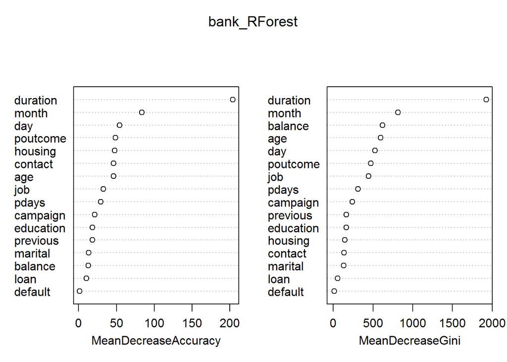

```r
varImpPlot(bank_RForest)
```

The ‘Accuracy’ variables that best explain if a client subscribes a term deposit are: *duration, month, day, poutcome*

The ‘Gini’ variables that best explain if a client subscribes a term deposit are: *duration, month, balance, age, day, poutcome*

```r
actual <- bank_validate_caret$y
bank_predicted <- predict(bank_RForest, newdata=bank_validate_caret, type="class")
bank_results.matrix.rf <- confusionMatrix(bank_predicted, actual, positive="yes")
print(bank_results.matrix.rf)
```

```
## Confusion Matrix and Statistics
##
##           Reference
## Prediction   no  yes
##        no  7741  602
##        yes  250  450
##
##                Accuracy : 0.9058
##                  95% CI : (0.8996, 0.9117)
##     No Information Rate : 0.8837
##     P-Value [Acc > NIR] : 8.192e-12
##
##                   Kappa : 0.4639
##  Mcnemar's Test P-Value : < 2.2e-16
##
##             Sensitivity : 0.42776
##             Specificity : 0.96871
##          Pos Pred Value : 0.64286
##          Neg Pred Value : 0.92784
##              Prevalence : 0.11633
##          Detection Rate : 0.04976
##    Detection Prevalence : 0.07741
##       Balanced Accuracy : 0.69824
##
##        'Positive' Class : yes
##
```

Specificity = 96.8% *When a client actually did not subscribe a term deposit, our model predicts no (did not subscribe a term deposit) 97% of the time*

### 2nd Random Forest Model

*5 predictors at a time & 800 trees created*

```r
bank_RForest2 = randomForest(y ~ ., data = bank_train_caret, mtry = 5, ntree = 800, na.action = na.omit, importance = TRUE)
# default to try 5 predictors at a time and create 800 trees
print(bank_RForest2)
```

```
##
## Call:
##  randomForest(formula = y ~ ., data = bank_train_caret, mtry = 5,      ntree = 800, importance = TRUE, na.action = na.omit)
##                Type of random forest: classification
##                      Number of trees: 800
## No. of variables tried at each split: 5
##
##         OOB estimate of  error rate: 9.12%
## Confusion matrix:
##        no  yes class.error
## no  30726 1205  0.03773762
## yes  2095 2142  0.49445362
```

```r
importance(bank_RForest2)
```

```
##                   no         yes MeanDecreaseAccuracy MeanDecreaseGini
## age        64.421100  14.4918260            68.624247        681.21245
## job        49.876908  -3.2930066            42.821150        496.06580
## marital    11.147607  16.8941717            19.247584        138.47996
## education  25.753914   2.3189419            25.073048        171.56298
## default     3.065512   0.2399766             2.929163         10.34247
## balance    10.105416  11.8160772            15.676982        742.06918
## housing    58.300647  32.0352383            68.987206        130.69846
## loan        7.417922  15.6739445            15.922570         52.55949
## contact    70.002147   3.8224606            72.021519        129.16376
## day        87.560824   5.8168723            86.877427        620.75505
## month     121.395528  41.6603551           127.422662        846.86437
## duration  202.517367 375.9049205           352.727221       2132.16512
## campaign   28.291156  12.6234286            30.968237        270.58429
## pdays      33.789754  35.2100213            37.864329        318.25359
## previous   20.024051  13.6102804            20.130962        150.47042
## poutcome   41.944276  22.8143005            60.853905        533.38167
```

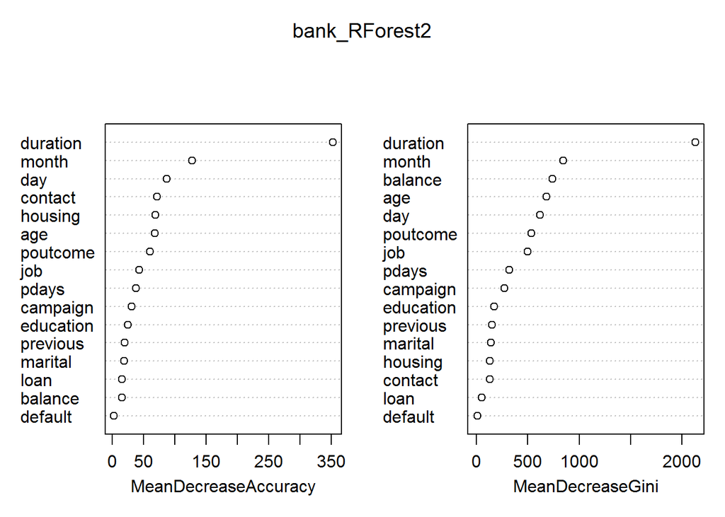

```r
varImpPlot(bank_RForest2)
```

```r
actual2 <- bank_validate_caret$y
bank_predicted2 <- predict(bank_RForest, newdata=bank_validate_caret, type="class")
bank_results.matrix.rf2 <- confusionMatrix(bank_predicted2, actual2, positive="yes")
print(bank_results.matrix.rf2)
```

```
## Confusion Matrix and Statistics
##
##           Reference
## Prediction   no  yes
##        no  7743  603
##        yes  248  449
##
##                Accuracy : 0.9059
##                  95% CI : (0.8997, 0.9118)
##     No Information Rate : 0.8837
##     P-Value [Acc > NIR] : 6.441e-12
##
##                   Kappa : 0.4637
##  Mcnemar's Test P-Value : < 2.2e-16
##
##             Sensitivity : 0.42681
##             Specificity : 0.96897
##          Pos Pred Value : 0.64419
##          Neg Pred Value : 0.92775
##              Prevalence : 0.11633
##          Detection Rate : 0.04965
##    Detection Prevalence : 0.07708
##       Balanced Accuracy : 0.69789
##
##        'Positive' Class : yes
##
```

# Recommendations

### Brief overview of model results:

Decision Tree - Accuracy = 89.8% Sensitivity = 35.1% Specificity = 97%

kNN - Accuracy = 89.4% Sensitivity = 16.9% Specificity = 98.9%

Logistic Regression - Unfortunately I was not able to validate my model and construct a confusion matrix to determine this model’s accuracy, sensitivity and specificity. However, the significant variables in predicting if a client subscribes a term deposit are: jobblue-collar, jobhousemaid, jobstudent, educationtertiary, housingyes, loanyes, contactunknown, day, monthaug, monthdec, monthjan, monthjul, monthjun, monthmar, monthmay, monthnov, monthoct, monthsep, duration, campaign, poutcomesuccess